# Ananlysis Of Titanic Data

## Overview

This report is an analysis of Titanic data from the dataset on Kaggle website. It contains information about passengers on its maiden voyage including details about their age, class, sex, fare, survival etc. Here I attempt to analyze: 1) How age,sex,class,fare impact survival rate and 2) Which type of passengers were given more preference.

```python
import csv
from datetime import datetime
import numpy as np
import pandas as pd
import matplotlib.pyplot as plt
%matplotlib inline
import seaborn as sns

titanic_df=pd.read_csv('titanic-data.csv')
titanic_df.head()
```

|  | PassengerId | Survived | Pclass | Name | Sex | Age | SibSp | Parch | Ticket | Fare | Cabin | Embarked |
| --- | --- | --- | --- | --- | --- | --- | --- | --- | --- | --- | --- | --- |
| 0 | 1 | 0 | 3 | Braund, Mr. Owen Harris | male | 22.0 | 1 | 0 | A/5 21171 | 7.2500 | NaN | S |
| 1 | 2 | 1 | 1 | Cumings, Mrs. John Bradley (Florence Briggs Th... | female | 38.0 | 1 | 0 | PC 17599 | 71.2833 | C85 | C |
| 2 | 3 | 1 | 3 | Heikkinen, Miss. Laina | female | 26.0 | 0 | 0 | STON/O2. 3101282 | 7.9250 | NaN | S |
| 3 | 4 | 1 | 1 | Futrelle, Mrs. Jacques Heath (Lily May Peel) | female | 35.0 | 1 | 0 | 113803 | 53.1000 | C123 | S |
| 4 | 5 | 0 | 3 | Allen, Mr. William Henry | male | 35.0 | 0 | 0 | 373450 | 8.0500 | NaN | S |

These are first few lines of Dataset.

```python
titanic_df.describe()
```

|  | PassengerId | Survived | Pclass | Age | SibSp | Parch | Fare |
| --- | --- | --- | --- | --- | --- | --- | --- |
| count | 891.000000 | 891.000000 | 891.000000 | 714.000000 | 891.000000 | 891.000000 | 891.000000 |
| mean | 446.000000 | 0.383838 | 2.308642 | 29.699118 | 0.523008 | 0.381594 | 32.204208 |
| std | 257.353842 | 0.486592 | 0.836071 | 14.526497 | 1.102743 | 0.806057 | 49.693429 |
| min | 1.000000 | 0.000000 | 1.000000 | 0.420000 | 0.000000 | 0.000000 | 0.000000 |
| 25% | 223.500000 | 0.000000 | 2.000000 | 20.125000 | 0.000000 | 0.000000 | 7.910400 |
| 50% | 446.000000 | 0.000000 | 3.000000 | 28.000000 | 0.000000 | 0.000000 | 14.454200 |
| 75% | 668.500000 | 1.000000 | 3.000000 | 38.000000 | 1.000000 | 0.000000 | 31.000000 |
| max | 891.000000 | 1.000000 | 3.000000 | 80.000000 | 8.000000 | 6.000000 | 512.329200 |

According to above information there are infants below 1year and senior citizens of age 80 travelled in Titanic ship. And some people travelled with zero fare.

```python
(titanic_df[['Age','Fare','Embarked','Cabin']]== 0).sum()
```

```
Age          0
Fare        15
Embarked     0
Cabin        0
dtype: int64
```

In Fare column there were 15 people travelling with zero fare. There might be a chance that these passenger are crew members or they got complimentary ticket.

```python
titanic_df.isnull().sum()
```

```
PassengerId      0
Survived         0
Pclass           0
Name             0
Sex              0
Age            177
SibSp            0
Parch            0
Ticket           0
Fare             0
Cabin          687
Embarked         2
dtype: int64
```

This shows that there are some missing infrormation in Age, Cabin and Embarked columns. Cabin data is almost missing.

```python
#How many survived
survival_count=titanic_df.Survived.value_counts()
survival_count.index = ["NotSurvived","Survived"]
survival_count
```

```
NotSurvived    549
Survived       342
Name: Survived, dtype: int64
```

Out of 891 Passengers. 342 were alive and 549 were dead

```python
#Gender influence on survival
titanic_df.groupby(['Survived','Sex'],as_index=False)['PassengerId'].count()
```

|  | Survived | Sex | PassengerId |
| --- | --- | --- | --- |
| 0 | 0 | female | 81 |
| 1 | 0 | male | 468 |
| 2 | 1 | female | 233 |
| 3 | 1 | male | 109 |

```python
titanic_df.groupby(['Embarked','Pclass'])['Survived'].mean()
```

```
Embarked  Pclass
C         1         0.694118
          2         0.529412
          3         0.378788
Q         1         0.500000
          2         0.666667
          3         0.375000
S         1         0.582677
          2         0.463415
          3         0.189802
Name: Survived, dtype: float64
```

## Dealing with missing Data

```python
#Droping Cabin column because many values are missing
titanic_df=titanic_df.drop(['Cabin'],1)
#Dropping rows of missing ages
titanic_df_new=titanic_df[titanic_df.Age.notnull()]
```

Cabin data is almost missing for all passengers. So dropped that column. The age of 177 passengers is missing. The idea of replacing those values with mean or median is not a good idea. In one case when analyzing impact of age on survival I dropped all rows that has missing ages. For rest of the analysis I didnot make any changes with respect to age. Similarly, followed the same process of dropping rows when analyzing impact of fare. But explanation is avaiable in further report.

### Replacing NaN's in Embarked column

```python
#finding most repeated value in Embarked column
titanic_df['Embarked'].mode()
```

```
0    S
dtype: object
```

```python
titanic_df[titanic_df.Embarked.isnull()]
```

|  | PassengerId | Survived | Pclass | Name | Sex | Age | SibSp | Parch | Ticket | Fare | Embarked |
| --- | --- | --- | --- | --- | --- | --- | --- | --- | --- | --- | --- |
| 61 | 62 | 1 | 1 | Icard, Miss. Amelie | female | 38.0 | 0 | 0 | 113572 | 80.0 | NaN |
| 829 | 830 | 1 | 1 | Stone, Mrs. George Nelson (Martha Evelyn) | female | 62.0 | 0 | 0 | 113572 | 80.0 | NaN |

```python
def replace_Embarked(value):
    """
    replacing NaN in Embarked column with most frequent value
    """
    value = np.where(pd.isnull(value),'S',value)
    return value
titanic_df['Embarked']=titanic_df['Embarked'].apply(replace_Embarked)
titanic_df.loc[829]
```

```
PassengerId                                          830
Survived                                               1
Pclass                                                 1
Name           Stone, Mrs. George Nelson (Martha Evelyn)
Sex                                               female
Age                                                   62
SibSp                                                  0
Parch                                                  0
Ticket                                            113572
Fare                                                  80
Embarked                                               S
Name: 829, dtype: object
```

All NaN's in Embarked column is replaced with most frequent port of embarkation i.e Southampton('S'). Port of embarkation data is missing only for 2 data points. So replacing it by most frequent port doesn't cause error.

## Analyzing Data Based on Age

```python
"""
Adding new column Age_Category
"""
def agesurvival(row):
    if (row['Age']<15):
        val= 'child'
    elif (row['Age'] >= 15 and row['Age']<=30):
        val='young-adult'
    elif (row['Age'] >= 30 and row['Age']<=50):
        val='middle-aged'
    else:
        val= 'senior'
    return val
titanic_df_new['Age_Category']=titanic_df_new.apply(agesurvival,axis=1)
titanic_df_new.head()
```

|  | PassengerId | Survived | Pclass | Name | Sex | Age | SibSp | Parch | Ticket | Fare | Embarked | Age_Category |
| --- | --- | --- | --- | --- | --- | --- | --- | --- | --- | --- | --- | --- |
| 0 | 1 | 0 | 3 | Braund, Mr. Owen Harris | male | 22.0 | 1 | 0 | A/5 21171 | 7.2500 | S | young-adult |
| 1 | 2 | 1 | 1 | Cumings, Mrs. John Bradley (Florence Briggs Th... | female | 38.0 | 1 | 0 | PC 17599 | 71.2833 | C | middle-aged |
| 2 | 3 | 1 | 3 | Heikkinen, Miss. Laina | female | 26.0 | 0 | 0 | STON/O2. 3101282 | 7.9250 | S | young-adult |
| 3 | 4 | 1 | 1 | Futrelle, Mrs. Jacques Heath (Lily May Peel) | female | 35.0 | 1 | 0 | 113803 | 53.1000 | S | middle-aged |
| 4 | 5 | 0 | 3 | Allen, Mr. William Henry | male | 35.0 | 0 | 0 | 373450 | 8.0500 | S | middle-aged |

```python
# Gouping data based on Age_Category
titanic_age_df = titanic_df_new.groupby(['Age_Category','Survived'],as_index=False)['PassengerId'].count()
# Create a custom sort
sorter=['child','young-adult', 'middle-aged','senior']
# Create the dictionary that defines the order for sorting
sorterIndex = dict(zip(sorter,range(len(sorter))))
titanic_age_df['AgeClassRank'] = titanic_age_df['Age_Category'].map(sorterIndex)
titanic_age_df.sort_values('AgeClassRank', ascending = True , inplace = True)
titanic_age_df
```

|  | Age_Category | Survived | PassengerId | AgeClassRank |
| --- | --- | --- | --- | --- |
| 0 | child | 0 | 33 | 0 |
| 1 | child | 1 | 45 | 0 |
| 6 | young-adult | 0 | 210 | 1 |
| 7 | young-adult | 1 | 121 | 1 |
| 2 | middle-aged | 0 | 139 | 2 |
| 3 | middle-aged | 1 | 102 | 2 |
| 4 | senior | 0 | 42 | 3 |
| 5 | senior | 1 | 22 | 3 |

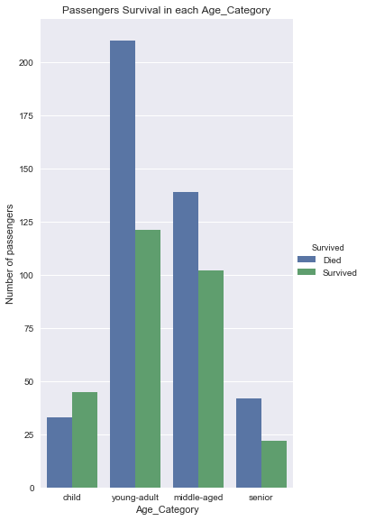

```python
#Plotting survival rate in each age_category
titanic_age_df['Survived'].replace({0:'Died', 1:'Survived'}, inplace=True)
g = sns.factorplot(x='Age_Category', y='PassengerId', hue='Survived',data=titanic_age_df,
                   size=8, kind='bar', aspect=.6,legend=True)
g.set_ylabels('Number of passengers')
plt.title('Passengers Survival in each Age_Category')
```

## Analyzing Data Based on Pclass

```python
#Retrieving data to show survival rate between men and women with respect to Pclass
survival_count_data=titanic_df.groupby(['Pclass','Sex','Survived'],as_index=False)['PassengerId'].count()
survived_data = survival_count_data[survival_count_data['Survived']==1]
notsurvived_data=survival_count_data[survival_count_data['Survived']==0]
notsurvived_data
```

|  | Pclass | Sex | Survived | PassengerId |
| --- | --- | --- | --- | --- |
| 0 | 1 | female | 0 | 3 |
| 2 | 1 | male | 0 | 77 |
| 4 | 2 | female | 0 | 6 |
| 6 | 2 | male | 0 | 91 |
| 8 | 3 | female | 0 | 72 |
| 10 | 3 | male | 0 | 300 |

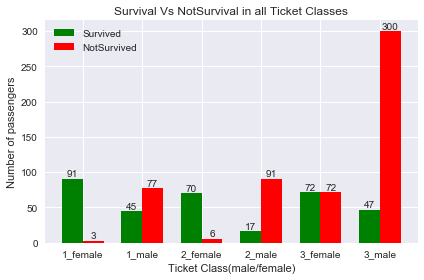

```python
import seaborn as sns
%matplotlib inline

fig, ax = plt.subplots()

index = np.arange(6)
bar_width = 0.35
tick_list=['1_female','1_male','2_female','2_male','3_female','3_male']
rects1 = ax.bar(index, survived_data['PassengerId'], bar_width,
                 color='g',
                 label='Survived')
rects2 = ax.bar(index + bar_width, notsurvived_data['PassengerId'], bar_width,
                 color='r',
                 label='NotSurvived')
def autolabel(rects):
    """
    Attach a text label above each bar displaying its height
    """
    for rect in rects:
        height = rect.get_height()
        ax.text(rect.get_x() + rect.get_width()/2., 1*height,
                '%d' % int(height),
                ha='center', va='bottom')

autolabel(rects1)
autolabel(rects2)

plt.xlabel('Ticket Class(male/female)')
plt.ylabel('Number of passengers')
plt.title('Survival Vs NotSurvival in all Ticket Classes')
plt.xticks(index + bar_width/2, tick_list)


plt.legend()

plt.tight_layout()
plt.show()
```

This bar graph shows how many female and male passengers were alive/notalive in each class. Majority of passengers are from Pclass 3 and their survival rate is also less. Almost all females survived in Pclass 1&2.

```python
# retrieving not survived female passenger information in 1st and 2nd class
survived_0_data=titanic_df[titanic_df['Survived']==0]
pclass_1_data=survived_0_data[survived_0_data['Pclass']==1]
pclass_2_data=survived_0_data[survived_0_data['Pclass']==2]
pclass_1_data[pclass_1_data['Sex']=='female']
```

|  | PassengerId | Survived | Pclass | Name | Sex | Age | SibSp | Parch | Ticket | Fare | Embarked |
| --- | --- | --- | --- | --- | --- | --- | --- | --- | --- | --- | --- |
| 177 | 178 | 0 | 1 | Isham, Miss. Ann Elizabeth | female | 50.0 | 0 | 0 | PC 17595 | 28.7125 | C |
| 297 | 298 | 0 | 1 | Allison, Miss. Helen Loraine | female | 2.0 | 1 | 2 | 113781 | 151.5500 | S |
| 498 | 499 | 0 | 1 | Allison, Mrs. Hudson J C (Bessie Waldo Daniels) | female | 25.0 | 1 | 2 | 113781 | 151.5500 | S |

```python
pclass_2_data[pclass_2_data['Sex']=='female']
```

|  | PassengerId | Survived | Pclass | Name | Sex | Age | SibSp | Parch | Ticket | Fare | Embarked |
| --- | --- | --- | --- | --- | --- | --- | --- | --- | --- | --- | --- |
| 41 | 42 | 0 | 2 | Turpin, Mrs. William John Robert (Dorothy Ann ... | female | 27.0 | 1 | 0 | 11668 | 21.0 | S |
| 199 | 200 | 0 | 2 | Yrois, Miss. Henriette ("Mrs Harbeck") | female | 24.0 | 0 | 0 | 248747 | 13.0 | S |
| 312 | 313 | 0 | 2 | Lahtinen, Mrs. William (Anna Sylfven) | female | 26.0 | 1 | 1 | 250651 | 26.0 | S |
| 357 | 358 | 0 | 2 | Funk, Miss. Annie Clemmer | female | 38.0 | 0 | 0 | 237671 | 13.0 | S |
| 772 | 773 | 0 | 2 | Mack, Mrs. (Mary) | female | 57.0 | 0 | 0 | S.O./P.P. 3 | 10.5 | S |
| 854 | 855 | 0 | 2 | Carter, Mrs. Ernest Courtenay (Lilian Hughes) | female | 44.0 | 1 | 0 | 244252 | 26.0 | S |

Total 9female passengers didnot survive in 1st and 2nd class. It is interesting to see that 8 passengers out of 9are from Southampton.

## Analyzing Data Based on Fare

```python
#Passengers who paid zero fare
titanic_df[titanic_df['Fare']==0]
```

|  | PassengerId | Survived | Pclass | Name | Sex | Age | SibSp | Parch | Ticket | Fare | Embarked |
| --- | --- | --- | --- | --- | --- | --- | --- | --- | --- | --- | --- |
| 179 | 180 | 0 | 3 | Leonard, Mr. Lionel | male | 36.0 | 0 | 0 | LINE | 0.0 | S |
| 263 | 264 | 0 | 1 | Harrison, Mr. William | male | 40.0 | 0 | 0 | 112059 | 0.0 | S |
| 271 | 272 | 1 | 3 | Tornquist, Mr. William Henry | male | 25.0 | 0 | 0 | LINE | 0.0 | S |
| 277 | 278 | 0 | 2 | Parkes, Mr. Francis "Frank" | male | NaN | 0 | 0 | 239853 | 0.0 | S |
| 302 | 303 | 0 | 3 | Johnson, Mr. William Cahoone Jr | male | 19.0 | 0 | 0 | LINE | 0.0 | S |
| 413 | 414 | 0 | 2 | Cunningham, Mr. Alfred Fleming | male | NaN | 0 | 0 | 239853 | 0.0 | S |
| 466 | 467 | 0 | 2 | Campbell, Mr. William | male | NaN | 0 | 0 | 239853 | 0.0 | S |
| 481 | 482 | 0 | 2 | Frost, Mr. Anthony Wood "Archie" | male | NaN | 0 | 0 | 239854 | 0.0 | S |
| 597 | 598 | 0 | 3 | Johnson, Mr. Alfred | male | 49.0 | 0 | 0 | LINE | 0.0 | S |
| 633 | 634 | 0 | 1 | Parr, Mr. William Henry Marsh | male | NaN | 0 | 0 | 112052 | 0.0 | S |
| 674 | 675 | 0 | 2 | Watson, Mr. Ennis Hastings | male | NaN | 0 | 0 | 239856 | 0.0 | S |
| 732 | 733 | 0 | 2 | Knight, Mr. Robert J | male | NaN | 0 | 0 | 239855 | 0.0 | S |
| 806 | 807 | 0 | 1 | Andrews, Mr. Thomas Jr | male | 39.0 | 0 | 0 | 112050 | 0.0 | S |
| 815 | 816 | 0 | 1 | Fry, Mr. Richard | male | NaN | 0 | 0 | 112058 | 0.0 | S |
| 822 | 823 | 0 | 1 | Reuchlin, Jonkheer. John George | male | 38.0 | 0 | 0 | 19972 | 0.0 | S |

These passengers paid zero fare. All were from Southampton. Everyone died except one. They does not belong to siblings/spouses or parents/children. Some of their ages are available but their age doesnot seem to be they travelled with nanny. They might belong to crew of Titanic ship or they got a complimentary ticket.

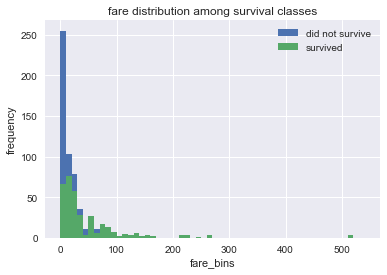

```python
#Collecting data only for those who paid fare
nonzero_fare_data=titanic_df[titanic_df['Fare']!=0]
#Plotting histogram to see survival rate based on fare
fare_bins = np.arange(0,550,10)
plt.hist(nonzero_fare_data.loc[(nonzero_fare_data['Survived']==0) ,'Fare'], bins=fare_bins)
plt.hist(nonzero_fare_data.loc[(nonzero_fare_data['Survived']==1) ,'Fare'], bins=fare_bins)
plt.title('fare distribution among survival classes')
plt.ylabel('frequency')
plt.xlabel('fare_bins')
plt.legend(['did not survive', 'survived']);
```

There is spike in this distribution at (0-10) bin-size. It means majority of people who paid fare between 1-10 did not survive. To further analyze I created a new column fare_categories. According to fare paid by passengers they will be assigned to 1,2,3,4,5,6 or 7th fare_categories.

```python
#Dropping passengers who paid zero fare
nonzero_fare_data=titanic_df[titanic_df['Fare']!=0]
bin=[1,10,20,40,70,100,200,600]
#lesser fare_group_name paid more fare
fare_group_names=['7','6','5','4','3','2','1']
#creating new column fare_categories
nonzero_fare_data['fare_categories']=pd.cut(nonzero_fare_data['Fare'],bin,labels=fare_group_names)
#grouping by fare_categories
fare_data=nonzero_fare_data.groupby(['fare_categories','Survived','Sex'],as_index=False)['PassengerId'].count()
fare_data_survived=fare_data[fare_data['Survived']==1]
fare_survived_female=fare_data_survived[fare_data_survived['Sex']=='female']
fare_survived_male=fare_data_survived[fare_data_survived['Sex']=='male']
fare_data_notsurvived=fare_data[fare_data['Survived']==0]
fare_notsurvived_female=fare_data_notsurvived[fare_data_notsurvived['Sex']=='female']
fare_notsurvived_male=fare_data_notsurvived[fare_data_notsurvived['Sex']=='male']
print(fare_notsurvived_male)
print(fare_survived_female)
```

```
   fare_categories  Survived   Sex  PassengerId
1                1         0  male          6.0
5                2         0  male          6.0
9                3         0  male         15.0
13               4         0  male         29.0
17               5         0  male         87.0
21               6         0  male         82.0
25               7         0  male        229.0
   fare_categories  Survived     Sex  PassengerId
2                1         1  female         12.0
6                2         1  female         20.0
10               3         1  female         30.0
14               4         1  female         24.0
18               5         1  female         52.0
22               6         1  female         57.0
26               7         1  female         38.0
```

229 males died in fare category 7 i.e (1-10)

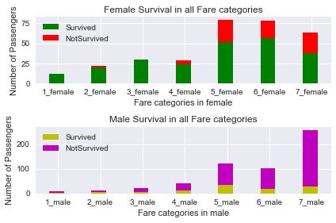

```python
#Plotting survival rate in each fare_categories
fig, ax = plt.subplots(2)

index = np.arange(7)
bar_width = 0.35

ax[0].bar(index, fare_survived_female['PassengerId'], bar_width,
                 color='g')
ax[0].bar(index ,  fare_notsurvived_female['PassengerId'],bar_width,bottom=fare_survived_female['PassengerId'],
                 color='r')

ax[0].set_xlabel('Fare categories in female')
ax[0].set_ylabel('Number of Passengers')
ax[0].set_title('Female Survival in all Fare categories')
ax[0].set_xticks(index + bar_width/10)
ax[0].set_xticklabels(('1_female','2_female','3_female','4_female','5_female','6_female','7_female'))

ax[1].bar(index, fare_survived_male['PassengerId'], bar_width,
                 color='y')
ax[1].bar(index ,  fare_notsurvived_male['PassengerId'],bar_width,bottom=fare_survived_male['PassengerId'],
                 color='m')

ax[1].set_xlabel('Fare categories in male')
ax[1].set_ylabel('Number of Passengers')
ax[1].set_title('Male Survival in all Fare categories')
ax[1].set_xticks(index + bar_width/10)
ax[1].set_xticklabels(('1_male','2_male','3_male','4_male','5_male','6_male','7_male'))

ax[0].legend(('Survived', 'NotSurvived'))
ax[1].legend(('Survived', 'NotSurvived'))


plt.tight_layout()
plt.show()
```

This graph clearly shows that majority of passengers are from 5,6,&7 fare categories. And large part of males didnot survive from these categories. It is also interesting to see that female survival is more than male. Almost all female passengers survived in higher categories.

## Analyzing Data Based on Port Of Embarkation

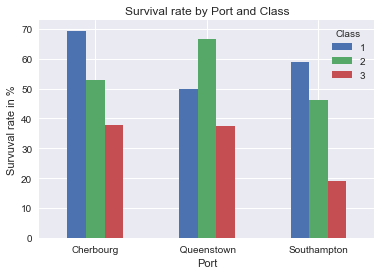

```python
#Plotting survival in each port with respect to Pclass
#titanic_df['Survived'].replace({0:'Died', 1:'Survived'}, inplace=True)
gb=titanic_df.groupby(['Embarked','Pclass'])['Survived'].mean().unstack()*100
ax=gb.plot.bar()
ax.set_xlabel('Port')
ax.set_ylabel('Survuval rate in %')
ax.set_title('Survival rate by Port and Class')
ax.set_xticklabels(('Cherbourg',' Queenstown','Southampton'),rotation=0)
ax.legend(title='Class')
```

It seems majority of passengers are from Southampton but their survival rate is less.

```python
# Retrieving survival information with respect to port of embarkation
Embarked_data=titanic_df.groupby(['Embarked','Survived','Sex'],as_index=False)['PassengerId'].count()
Embarked_Survived=Embarked_data[Embarked_data['Survived']==1]
print(Embarked_Survived)
Embarked_NotSurvived=Embarked_data[Embarked_data['Survived']==0]
print(Embarked_NotSurvived)
```

```
   Embarked  Survived     Sex  PassengerId
2         C         1  female           64
3         C         1    male           29
6         Q         1  female           27
7         Q         1    male            3
10        S         1  female          142
11        S         1    male           77
  Embarked  Survived     Sex  PassengerId
0        C         0  female            9
1        C         0    male           66
4        Q         0  female            9
5        Q         0    male           38
8        S         0  female           63
9        S         0    male          364
```

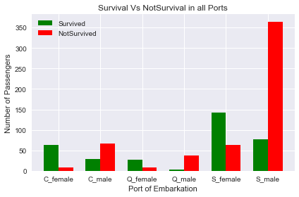

```python
#Plotting survival rate in each port of embarkation
tick_list=['C_female','C_male','Q_female','Q_male','S_female','S_male']
fig, ax = plt.subplots()

index = np.arange(6)
bar_width = 0.35

rects1 = ax.bar(index, Embarked_Survived['PassengerId'], bar_width,
                 color='g',
                 label='Survived')
rects2 = ax.bar(index + bar_width, Embarked_NotSurvived['PassengerId'], bar_width,
                 color='r',
                 label='NotSurvived')



plt.xlabel('Port of Embarkation')
plt.ylabel('Number of Passengers')
plt.title('Survival Vs NotSurvival in all Ports')
plt.xticks(index + bar_width/2, tick_list)


plt.legend()

plt.tight_layout()
plt.show()
```

## Conclusion

Total of 891 passengers data was available. 342 were alive and 549 were dead. 314 females travelled out of which 233 Survived. 577 males travelled out of which 109 survived. It is clear that gender has influence on survival. Chlidren and female are given more preferrence than male. Class also has influence on survival. Almost all females survived from Pclass 1&2. Majority of passengers are from Pclass 3 and their survival rate is also less when compared to others.

Total number of passengers travelled in Titanic was 1,317 but this analysis is made for 891 passengers. And the age of 177 people is missing. If additional information like passengers belong to which deck is provived then this analysis might give much more accurate insights regarding passengers survival.

## References

1)Stack Overflow 2)Udacity Forum 3)Matplotlib 4)http://machinelearningmastery.com/handle-missing-data-python/ 5)http://pandas.pydata.org/pandas-docs/version/0.18.1/generated/pandas.DataFrame.plot.box.html 6)http://seaborn.pydata.org/